# Trait review recovery: situation and next steps

Raw-stage reconciliation of archived review work with current candidates

Published

August 14, 2026

## Executive summary

**ImportantCurrent status**

The recovery is complete, but scientific approval is not.

The current raw-stage queue contains 4,295 mandatory taxon-trait candidates. Every candidate now has an auditable relationship to the archived report, the submitted correction table, and the recovered proposal table. No recovered correction or inferred no-action decision has been approved automatically.

The archived PDF reports contain 4,278 taxon-trait groups, of which 2,511 fall inside the review scope documented in the accompanying note. Of those historically reviewed groups, 2,490 still match the current candidate queue exactly. The difference reflects taxonomic and candidate-set changes since the reports were produced; it is not evidence that the earlier work was lost.

The submitted correction table contains 1,879 rows covering 1,875 current candidate groups. Conservative parsing recovered 330 atomic correction proposals covering 329 candidate groups, while 1,549 submitted rows remain too ambiguous for automatic conversion.

## What the counts mean

Remaining-work categories for current raw candidates.

| Priority | Category | Candidates | Share of queue |
| --- | --- | --- | --- |
| 1 | Recovered correction: validate | 328 | 7.6% |
| 2 | Submitted correction: interpret | 1,547 | 36.0% |
| 3 | Previous no-action: revalidate | 645 | 15.0% |
| 4 | Historical review unfinished | 1,760 | 41.0% |
| 5 | New or changed candidate | 15 | 0.3% |

These categories are mutually exclusive and sum to the complete queue. They are workflow categories rather than scientific conclusions.

- **Recovered correction: validate** means the submitted wording could be converted into a structured selector and action, but a person must confirm the interpretation and evidence.
- **Submitted correction: interpret** means a submitted row exists, but its wording, duplicate structure, qualifier, or graph reference requires visual scientific review.
- **Previous no-action: revalidate** means the candidate lies within confirmed historical review scope but has no submitted correction row; this is the strongest evidence for an implicit no-action decision, but it still requires explicit confirmation under the new auditable contract.
- **Historical review unfinished** means the candidate was present in an archived report outside the documented completed scope.
- **New or changed candidate** means the current candidate was not present in the archived report and has no submitted correction requiring interpretation.

## Where the work remains

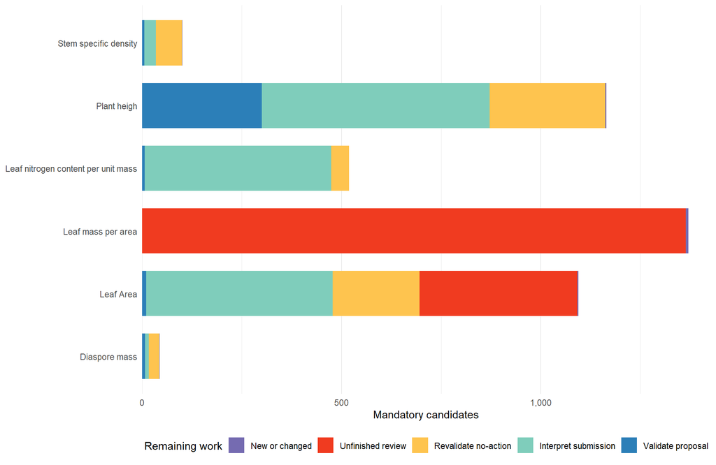

Candidates by trait domain and remaining-review category.

Candidate counts by domain and remaining-work category.

| Trait domain | Remaining-work category | Candidates |
| --- | --- | --- |
| Diaspore mass | New or changed candidate | 1 |
| Diaspore mass | Previous no-action: revalidate | 26 |
| Diaspore mass | Recovered correction: validate | 7 |
| Diaspore mass | Submitted correction: interpret | 10 |
| Leaf Area | New or changed candidate | 3 |
| Leaf Area | Previous no-action: revalidate | 218 |
| Leaf Area | Recovered correction: validate | 10 |
| Leaf Area | Submitted correction: interpret | 468 |
| Leaf Area | Historical review unfinished | 396 |
| Leaf mass per area | New or changed candidate | 7 |
| Leaf mass per area | Historical review unfinished | 1,364 |
| Leaf nitrogen content per unit mass | Previous no-action: revalidate | 45 |
| Leaf nitrogen content per unit mass | Recovered correction: validate | 6 |
| Leaf nitrogen content per unit mass | Submitted correction: interpret | 468 |
| Plant heigh | New or changed candidate | 3 |
| Plant heigh | Previous no-action: revalidate | 290 |
| Plant heigh | Recovered correction: validate | 300 |
| Plant heigh | Submitted correction: interpret | 572 |
| Stem specific density | New or changed candidate | 1 |
| Stem specific density | Previous no-action: revalidate | 66 |
| Stem specific density | Recovered correction: validate | 5 |
| Stem specific density | Submitted correction: interpret | 29 |

## What can be retained from the earlier review

The historical note records complete review of Diaspore mass, Leaf nitrogen content per unit mass, Plant heigh, and Stem specific density. It records Leaf Area as reviewed through PDF page 700 and contains no completed-review claim for Leaf mass per area.

Page 1 of the Leaf Area PDF is the table of contents, so review through PDF page 700 covers 699 historical taxon-trait pages. Of these, 694 still match current candidates exactly.

Archived report coverage and exact current matches.

| Trait domain | Report groups | Inside documented review scope | Current confirmed matches | Current unfinished matches | Current candidates absent from report |
| --- | --- | --- | --- | --- | --- |
| Diaspore mass | 43 | 43 | 41 | 0 | 3 |
| Leaf Area | 1,095 | 699 | 694 | 396 | 5 |
| Leaf mass per area | 1,371 | 0 | 0 | 1,364 | 7 |
| Leaf nitrogen content per unit mass | 518 | 518 | 516 | 0 | 3 |
| Plant heigh | 1,150 | 1,150 | 1,140 | 0 | 25 |
| Stem specific density | 101 | 101 | 99 | 0 | 2 |

The 645 candidates classified as previous no-action candidates are not being treated as approved. They are a high-confidence review shortcut: confirm that their current distributions still support no change, then record explicit approved `none` decisions.

## Why proposal counts and candidate counts differ

The recovery generated 330 atomic proposals for 329 candidate groups. The mutually exclusive queue contains fewer candidates in the recovered-correction category because one candidate has both a structured proposal and a pending submitted row; the more cautious submitted-correction interpretation category takes precedence for that candidate.

This distinction prevents duplicate rows from being mistaken for independent candidate groups and prevents an easily parsed fragment from hiding unresolved wording for the same candidate.

## Recommended next steps

### 1. Validate recovered corrections

Review the structured proposals first because they offer the fastest path to safe, auditable decisions. For each proposal, confirm the taxon, domain, optional trait-name or value selector, action, scale factor, rationale, and evidence. Keep the status as `proposed` until a named human reviewer records approval and a review date.

### 2. Interpret ambiguous submitted corrections

Process the submitted-correction interpretation category in bounded batches split by trait domain, `trait_name`, and dataset. Consult the archived plots and the original notes, then translate each conclusion into one or more atomic decision rows. Do not apply free-text notes directly to all values for a taxon-domain group.

### 3. Revalidate probable no-action candidates

Review the previous no-action category using compact distribution panels and dataset splits. Where the current evidence still supports no correction, record an explicit approved `action = "none"` decision. Escalate any changed distribution to a normal correction review rather than preserving the historical conclusion automatically.

### 4. Finish the historically incomplete domains

Complete the remaining Leaf Area pages first because they continue an already-started review. Then review Leaf mass per area in full; this domain has no documented completed historical review.

### 5. Review new or changed candidates

Inspect candidates absent from the archived report after the historical work is reconciled. Their small number makes them suitable for individual review rather than automated inference.

### 6. Close the raw review gate

The raw gate is complete only when every current candidate has either an approved correction or an explicit approved no-action decision. Before applying decisions, require every approved correction to match at least one record, reject overlapping or conflicting rules, and inspect before-and-after distributions and record counts for all six domains.

### 7. Repeat independently after classification

After approved raw decisions are applied, regenerate classified-taxon candidates and complete the classified-stage review independently. Raw approval must not be copied mechanically to classified taxa because classification changes the grouping contract.

## Limitations

- Historical completion is reconstructed from the archived reports and the accompanying note, not from an explicit row-level no-action ledger.
- A missing submitted correction row does not by itself prove that a candidate was reviewed; the historical report scope is required for that inference.
- Exact candidate hashes intentionally expose taxonomic or domain changes rather than silently matching them.
- Recovered proposals encode only unambiguous wording and remain scientific suggestions until human approval.
- Domain-level flags remain diagnostic context and are not mandatory review candidates by themselves.

## Reproducibility and source material

This report reads the generated reconciliation, historical-scope index, submission audit, and proposal table from `Data/Temp/Trait_corrections/raw/`. Regenerate those files with `R/03_Supplementary_analyses/One_time/Trait_corrections/recover_trait_review_submission.R`, then render this report with `R/03_Supplementary_analyses/One_time/Trait_corrections/render_trait_review_reconciliation_report.R`.

Immutable review-source checksums used for this report.

| Source | File | SHA-256 |
| --- | --- | --- |
| Submitted correction table | trait_manual_corrections.csv | 89def6e308d57bb4dc0c0a308bd02b7c001791c76959ba72fca573ba626b3b37 |
| Accompanying review note | review_notes.pdf | 666beaa4f2e34c620017ef4738ad08ae74c9f191d9050fcb613f3be45529175e |

Report generated from the current artifacts at 2026-08-14 12:34 CEST.